# PR1

### **What is Hospital Readmission?**

Hospital readmission happens when a patient who was discharged from a hospital needs to be admitted again within a short period of time —typically within **30 days**. This often means that:

✔ The patient’s condition was **not fully treated**  
✔ They didn’t receive **proper follow-up care**  
✔ There were **complications after discharge**

For patients with **diabetes**, hospital readmissions are especially common. Diabetes affects multiple organs, and poor management can lead to severe health problems requiring emergency care.

✔ **High readmission rates** put a strain on hospitals and healthcare workers  
✔ **Patients experience more stress and financial burden**  
✔ **Hospitals lose money** due to insurance penalties for excessive readmissions

If we can **predict which patients are likely to be readmitted**, hospitals can **intervene early**, provide **better post-discharge care**, and **reduce unnecessary hospital visits**.

I will use **machine learning** to analyze patient data and build a model that can **predict** whether a diabetic patient is **at risk of being readmitted within 30 days**.

To do this, I will:

1. **Explore patient data** to understand trends
2. **Clean and preprocess the dataset** to prepare it for machine learning
3. **Train different machine learning models** to find the best one
4. **Evaluate model performance** using accuracy and other metrics
5. **Deploy the model** so hospitals can use it to predict readmissions

This will help hospitals make **data-driven decisions** and improve patient care.

📌 **Kaggle Dataset:** [Diabetes 130 US Hospitals (1999-2008)](https://www.kaggle.com/datasets/brandao/diabetes)

✔ **100,000+ patient records** from **130 hospitals** across the United States  
✔ **Collected between 1999 and 2008**  
✔ Includes **patient demographics, medical history, lab tests, medications, and readmission status**

This dataset contains **over 50 features**, grouped into the following categories:

| Column Name | Description |
| --- | --- |
| patient_nbr | Unique identifier for each patient |
| age | Age group (e.g., 50-60, 70-80) |
| gender | Male or Female |
| race | Patient's race category |

| Column Name | Description |
| --- | --- |
| time_in_hospital | Number of days spent in the hospital |
| num_lab_procedures | Total number of lab tests performed |
| num_procedures | Number of medical procedures received |
| num_medications | Number of medications prescribed |
| number_diagnoses | Number of diagnoses assigned to the patient |

| Column Name | Description |
| --- | --- |
| diag_1, diag_2, diag_3 | Primary, secondary, and tertiary diagnoses |
| max_glu_serum | Glucose level test result (Normal/High) |
| A1Cresult | Hemoglobin A1C test result (diabetes indicator) |

[output not shown]

This **readmitted** column is what I will predict using **machine learning models**.

To develop a model for predicting **hospital readmissions**, I will:

1. **Explore and visualize the data** to identify trends
2. **Clean the dataset** – handle missing values and format variables
3. **Train different machine learning models** and compare their performance
4. **Optimize the best model** for accuracy and reliability
5. **Deploy the final model** so it can be used for real-time predictions

Now that I understand **what the dataset contains** and **why this project matters**, the next step is to **load the data into Python and start exploring it**.

Understanding the dataset before modeling is necessary. This step will help:

- Check how many records and features the dataset has
- Identify missing values that might need fixing
- Understand what type of data each column contains
- Look for any patterns or inconsistencies

If I skip this step, I might **train a model on incomplete or misleading data**, leading to **poor predictions**.

```python
import pandas as pd
import numpy as np
import matplotlib.pyplot as plt
import seaborn as sns
```

```python
pd.set_option("display.max_columns", None)
pd.set_option("display.float_format", "{:.2f}".format)
```

### What This Code Does

- pandas is used to handle and analyze tabular data.
- numpyis used for numerical operations.
- matplotlib and seaborn will be used later for data visualization.
- The pd.set_option() function ensures:
  - All columns are displayed when printing data.
  - Numbers are formatted to two decimal places for better readability.

```python
df = pd.read_csv(r"C:\Users\user\Desktop\pr project\diabetic_data.csv")
df.head()
```

|  | encounter_id | patient_nbr | race | gender | age | weight | admission_type_id | discharge_disposition_id | admission_source_id | time_in_hospital | payer_code | medical_specialty | num_lab_procedures | num_procedures | num_medications | number_outpatient | number_emergency | number_inpatient | diag_1 | diag_2 | diag_3 | number_diagnoses | max_glu_serum | A1Cresult | metformin | repaglinide | nateglinide | chlorpropamide | glimepiride | … |
| --- | --- | --- | --- | --- | --- | --- | --- | --- | --- | --- | --- | --- | --- | --- | --- | --- | --- | --- | --- | --- | --- | --- | --- | --- | --- | --- | --- | --- | --- | --- |
| 0 | 2278392 | 8222157 | Caucasian | Female | [0-10) | ? | 6 | 25 | 1 | 1 | ? | Pediatrics-Endocrinology | 41 | 0 | 1 | 0 | 0 | 0 | 250.83 | ? | ? | 1 | NaN | NaN | No | No | No | No | No | … |
| 1 | 149190 | 55629189 | Caucasian | Female | [10-20) | ? | 1 | 1 | 7 | 3 | ? | ? | 59 | 0 | 18 | 0 | 0 | 0 | 276 | 250.01 | 255 | 9 | NaN | NaN | No | No | No | No | No | … |
| 2 | 64410 | 86047875 | AfricanAmerican | Female | [20-30) | ? | 1 | 1 | 7 | 2 | ? | ? | 11 | 5 | 13 | 2 | 0 | 1 | 648 | 250 | V27 | 6 | NaN | NaN | No | No | No | No | No | … |
| 3 | 500364 | 82442376 | Caucasian | Male | [30-40) | ? | 1 | 1 | 7 | 2 | ? | ? | 44 | 1 | 16 | 0 | 0 | 0 | 8 | 250.43 | 403 | 7 | NaN | NaN | No | No | No | No | No | … |
| 4 | 16680 | 42519267 | Caucasian | Male | [40-50) | ? | 1 | 1 | 7 | 1 | ? | ? | 51 | 0 | 8 | 0 | 0 | 0 | 197 | 157 | 250 | 5 | NaN | NaN | No | No | No | No | No | … |

### Understanding the Output

- This code loads the dataset into a pandas DataFrame.
- The .head() function displays the first five rows to get an overview of the data.
- This helps in checking if the dataset is loaded correctly.

```python
df.shape
```

```
(101766, 50)
```

### What This Shows

- .shape returns the total number of rows and columns.
- This helps understand how large the dataset is before further processing.

```python
df.info()
```

```
<class 'pandas.core.frame.DataFrame'>
RangeIndex: 101766 entries, 0 to 101765
Data columns (total 50 columns):
 #   Column                    Non-Null Count   Dtype
---  ------                    --------------   -----
 0   encounter_id              101766 non-null  int64
 1   patient_nbr               101766 non-null  int64
 2   race                      101766 non-null  object
 3   gender                    101766 non-null  object
 4   age                       101766 non-null  object
 5   weight                    101766 non-null  object
 6   admission_type_id         101766 non-null  int64
 7   discharge_disposition_id  101766 non-null  int64
 8   admission_source_id       101766 non-null  int64
 9   time_in_hospital          101766 non-null  int64
```

[output cut: 42 more lines]

### Understanding the Output

- .info() displays:
  - Column names
  - Data types (integer, float, object)
  - Number of non-null values (helps identify missing data)
- This step helps in deciding whether we need to clean or transform any columns before modeling.

```python
missing_values = df.isnull().sum()
missing_values[missing_values > 0]
```

```
max_glu_serum    96420
A1Cresult        84748
dtype: int64
```

### What This Code Does

- .isnull().sum() counts the number of missing values in each column.
- The second line filters only columns where missing values exist.
- This helps in deciding whether to:
  - Fill missing values with averages or default values
  - Drop columns with too many missing values

```python
df.describe()
```

|  | encounter_id | patient_nbr | admission_type_id | discharge_disposition_id | admission_source_id | time_in_hospital | num_lab_procedures | num_procedures | num_medications | number_outpatient | number_emergency | number_inpatient | number_diagnoses |
| --- | --- | --- | --- | --- | --- | --- | --- | --- | --- | --- | --- | --- | --- |
| count | 101766.00 | 101766.00 | 101766.00 | 101766.00 | 101766.00 | 101766.00 | 101766.00 | 101766.00 | 101766.00 | 101766.00 | 101766.00 | 101766.00 | 101766.00 |
| mean | 165201645.62 | 54330400.69 | 2.02 | 3.72 | 5.75 | 4.40 | 43.10 | 1.34 | 16.02 | 0.37 | 0.20 | 0.64 | 7.42 |
| std | 102640295.98 | 38696359.35 | 1.45 | 5.28 | 4.06 | 2.99 | 19.67 | 1.71 | 8.13 | 1.27 | 0.93 | 1.26 | 1.93 |
| min | 12522.00 | 135.00 | 1.00 | 1.00 | 1.00 | 1.00 | 1.00 | 0.00 | 1.00 | 0.00 | 0.00 | 0.00 | 1.00 |
| 25% | 84961194.00 | 23413221.00 | 1.00 | 1.00 | 1.00 | 2.00 | 31.00 | 0.00 | 10.00 | 0.00 | 0.00 | 0.00 | 6.00 |
| 50% | 152388987.00 | 45505143.00 | 1.00 | 1.00 | 7.00 | 4.00 | 44.00 | 1.00 | 15.00 | 0.00 | 0.00 | 0.00 | 8.00 |
| 75% | 230270887.50 | 87545949.75 | 3.00 | 4.00 | 7.00 | 6.00 | 57.00 | 2.00 | 20.00 | 0.00 | 0.00 | 1.00 | 9.00 |
| max | 443867222.00 | 189502619.00 | 8.00 | 28.00 | 25.00 | 14.00 | 132.00 | 6.00 | 81.00 | 42.00 | 76.00 | 21.00 | 16.00 |

### What This Output Shows

- .describe() provides a summary of numerical columns, including:
  - Mean, min, and max values
  - Standard deviation (how spread out the data is)

```python
categorical_columns = ["race", "gender", "age", "readmitted"]
for col in categorical_columns:
    print(f"Unique values in {col}:", df[col].unique())
```

```
Unique values in race: ['Caucasian' 'AfricanAmerican' '?' 'Other' 'Asian' 'Hispanic']
Unique values in gender: ['Female' 'Male' 'Unknown/Invalid']
Unique values in age: ['[0-10)' '[10-20)' '[20-30)' '[30-40)' '[40-50)' '[50-60)' '[60-70)'
 '[70-80)' '[80-90)' '[90-100)']
Unique values in readmitted: ['NO' '>30' '<30']
```

### Why This Step is Important

- .unique() lists all distinct values in a column.
- Helps detect inconsistencies (e.g., spelling variations or errors in categorical data).
- Knowing the number of unique values also helps in deciding how to preprocess the data.

```python
pd.set_option("mode.use_inf_as_na", True)
```

```python
print("Missing values:", df["time_in_hospital"].isnull().sum())
print("Infinite values:", np.isinf(df["time_in_hospital"]).sum())
print("Unique values:", df["time_in_hospital"].unique())
```

```
Missing values: 0
Infinite values: 0
Unique values: [ 1  3  2  4  5 13 12  9  7 10  6 11  8 14]
```

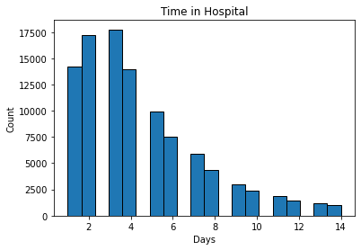

```python
plt.hist(df["time_in_hospital"], bins=20, edgecolor="black")
plt.title("Time in Hospital")
plt.xlabel("Days")
plt.ylabel("Count")
plt.show()
```

This histogram represents the **distribution of hospital stay durations** for patients in the dataset.

### **Why This Matters**

- Understanding **how long most patients stay** helps hospitals plan **bed availability and resource allocation**.
- Patients who have **shorter hospital stays** might be at **higher risk of readmission** if they were discharged too early.
- This trend can help identify **outliers**, such as **patients with unusually long or short hospital stays**, who might require special attention.

Before using this data in a machine learning model, I need to clean it.  
This step will help:

- Handle **missing values** so they don’t cause errors during training
- Convert **categorical features** into a format that machine learning models can understand
- Scale **numerical values** to ensure all features contribute equally to the model
- Identify and remove **irrelevant or duplicate features**

A clean dataset leads to **better accuracy and performance** when training the model.

```python
duplicate_rows = df.duplicated().sum()
duplicate_rows
```

```
0
```

### What This Code Does

- .duplicated().sum() counts the number of duplicate rows in the dataset.
- If duplicates exist, they should be removed to prevent bias in the model.

```python
missing_values = df.isnull().sum()
missing_values[missing_values > 0]
```

```
max_glu_serum    96420
A1Cresult        84748
dtype: int64
```

### What This Code Does

- .isnull().sum() counts missing values in each column.
- It then filters only columns that contain missing values.

```python
df = df.ffill()
```

### What This Code Does

- Forward fill fills missing values using the previous row's value.
- Works best for categorical and sequential data.

```python
df.isnull().sum()
```

```
encounter_id                  0
patient_nbr                   0
race                          0
gender                        0
age                           0
weight                        0
admission_type_id             0
discharge_disposition_id      0
admission_source_id           0
time_in_hospital              0
payer_code                    0
medical_specialty             0
num_lab_procedures            0
num_procedures                0
num_medications               0
number_outpatient             0
number_emergency              0
number_inpatient              0
diag_1                        0
diag_2                        0
diag_3                        0
number_diagnoses              0
max_glu_serum               133
A1Cresult                    26
metformin                     0
repaglinide                   0
nateglinide                   0
chlorpropamide                0
glimepiride                   0
acetohexamide                 0
glipizide                     0
glyburide                     0
tolbutamide                   0
pioglitazone                  0
rosiglitazone                 0
acarbose                      0
miglitol                      0
troglitazone                  0
tolazamide                    0
examide                       0
citoglipton                   0
insulin                       0
glyburide-metformin           0
glipizide-metformin           0
glimepiride-pioglitazone      0
metformin-rosiglitazone       0
metformin-pioglitazone        0
change                        0
diabetesMed                   0
readmitted                    0
dtype: int64
```

```python
df["max_glu_serum"].fillna("None", inplace=True)
df["A1Cresult"].fillna("None", inplace=True)
```

```python
df.isnull().sum()
```

```
encounter_id                0
patient_nbr                 0
race                        0
gender                      0
age                         0
weight                      0
admission_type_id           0
discharge_disposition_id    0
admission_source_id         0
time_in_hospital            0
payer_code                  0
medical_specialty           0
num_lab_procedures          0
num_procedures              0
num_medications             0
number_outpatient           0
number_emergency            0
number_inpatient            0
diag_1                      0
diag_2                      0
diag_3                      0
number_diagnoses            0
max_glu_serum               0
A1Cresult                   0
metformin                   0
repaglinide                 0
nateglinide                 0
chlorpropamide              0
glimepiride                 0
acetohexamide               0
glipizide                   0
glyburide                   0
tolbutamide                 0
pioglitazone                0
rosiglitazone               0
acarbose                    0
miglitol                    0
troglitazone                0
tolazamide                  0
examide                     0
citoglipton                 0
insulin                     0
glyburide-metformin         0
glipizide-metformin         0
glimepiride-pioglitazone    0
metformin-rosiglitazone     0
metformin-pioglitazone      0
change                      0
diabetesMed                 0
readmitted                  0
dtype: int64
```

After handling most missing values, only two columns still had missing data:

- **max_glu_serum** (Glucose test results)
- **A1Cresult** (A1C diabetes test results)

These columns represent lab tests, which are not always performed for every patient.  
Instead of dropping rows or guessing values, the best approach is to fill missing values with "None".

Most columns in the dataset are **numerical**, but some are **categorical**, meaning they contain text labels.  
Machine learning models only understand numbers, so I need to convert these categories into numerical format.

I will use **One-Hot Encoding**, which: **Creates new columns for each category**  
**Assigns 1 if the category is present, 0 otherwise**  
**Prevents numerical bias** (unlike label encoding)

```python
df = pd.get_dummies(df, columns=["gender", "race", "age"], drop_first=True)
df.head()
```

|  | encounter_id | patient_nbr | weight | admission_type_id | discharge_disposition_id | admission_source_id | time_in_hospital | payer_code | medical_specialty | num_lab_procedures | num_procedures | num_medications | number_outpatient | number_emergency | number_inpatient | diag_1 | diag_2 | diag_3 | number_diagnoses | max_glu_serum | A1Cresult | metformin | repaglinide | nateglinide | chlorpropamide | glimepiride | acetohexamide | glipizide | glyburide | … |
| --- | --- | --- | --- | --- | --- | --- | --- | --- | --- | --- | --- | --- | --- | --- | --- | --- | --- | --- | --- | --- | --- | --- | --- | --- | --- | --- | --- | --- | --- | --- |
| 0 | 2278392 | 8222157 | ? | 6 | 25 | 1 | 1 | ? | Pediatrics-Endocrinology | 41 | 0 | 1 | 0 | 0 | 0 | 250.83 | ? | ? | 1 | None | None | No | No | No | No | No | No | No | No | … |
| 1 | 149190 | 55629189 | ? | 1 | 1 | 7 | 3 | ? | ? | 59 | 0 | 18 | 0 | 0 | 0 | 276 | 250.01 | 255 | 9 | None | None | No | No | No | No | No | No | No | No | … |
| 2 | 64410 | 86047875 | ? | 1 | 1 | 7 | 2 | ? | ? | 11 | 5 | 13 | 2 | 0 | 1 | 648 | 250 | V27 | 6 | None | None | No | No | No | No | No | No | Steady | No | … |
| 3 | 500364 | 82442376 | ? | 1 | 1 | 7 | 2 | ? | ? | 44 | 1 | 16 | 0 | 0 | 0 | 8 | 250.43 | 403 | 7 | None | None | No | No | No | No | No | No | No | No | … |
| 4 | 16680 | 42519267 | ? | 1 | 1 | 7 | 1 | ? | ? | 51 | 0 | 8 | 0 | 0 | 0 | 197 | 157 | 250 | 5 | None | None | No | No | No | No | No | No | Steady | No | … |

```python
df.replace("?", np.nan, inplace=True)
df.isnull().sum()
```

```
encounter_id                    0
patient_nbr                     0
weight                      98569
admission_type_id               0
discharge_disposition_id        0
                            ...
age_[50-60)                     0
age_[60-70)                     0
age_[70-80)                     0
age_[80-90)                     0
age_[90-100)                    0
Length: 63, dtype: int64
```

### What This Code Does

- .replace("?", np.nan, inplace=True) converts all **"?" values into actual missing values (NaN)**.
- .isnull().sum() checks how many missing values exist in each column.

```python
df["weight"] = df["weight"].fillna("Unknown")
```

### What This Code Does

- Replaces missing values in weight with "Unknown" instead of deleting them.
- Preserves all patient records without introducing false values.
- Later, "Unknown" can be encoded as a separate category for machine learning.

```python
df.isnull().sum()
```

```
encounter_id                0
patient_nbr                 0
weight                      0
admission_type_id           0
discharge_disposition_id    0
                           ..
age_[50-60)                 0
age_[60-70)                 0
age_[70-80)                 0
age_[80-90)                 0
age_[90-100)                0
Length: 63, dtype: int64
```

Different numerical features have different **ranges of values**:

- time_in_hospital is between **1-14 days**.
- num_lab_procedures can be **hundreds**.
- num_medications can also be large.

If I don’t scale them, large numbers (like lab procedures) will dominate the model and small numbers (like hospital days) will be ignored. So I can standardize all numerical features so they have a mean of 0 and standard deviation of 1.

```python
numerical_cols = ["time_in_hospital", "num_lab_procedures", "num_medications", "number_diagnoses"]
```

```python
from sklearn.preprocessing import StandardScaler

scaler = StandardScaler()
df[numerical_cols] = scaler.fit_transform(df[numerical_cols])
df.head()
```

|  | encounter_id | patient_nbr | weight | admission_type_id | discharge_disposition_id | admission_source_id | time_in_hospital | payer_code | medical_specialty | num_lab_procedures | num_procedures | num_medications | number_outpatient | number_emergency | number_inpatient | diag_1 | diag_2 | diag_3 | number_diagnoses | max_glu_serum | A1Cresult | metformin | repaglinide | nateglinide | chlorpropamide | glimepiride | acetohexamide | glipizide | glyburide | … |
| --- | --- | --- | --- | --- | --- | --- | --- | --- | --- | --- | --- | --- | --- | --- | --- | --- | --- | --- | --- | --- | --- | --- | --- | --- | --- | --- | --- | --- | --- | --- |
| 0 | 2278392 | 8222157 | Unknown | 6 | 25 | 1 | -1.14 | NaN | Pediatrics-Endocrinology | -0.11 | 0 | -1.85 | 0 | 0 | 0 | 250.83 | NaN | NaN | -3.32 | None | None | No | No | No | No | No | No | No | No | … |
| 1 | 149190 | 55629189 | Unknown | 1 | 1 | 7 | -0.47 | NaN | NaN | 0.81 | 0 | 0.24 | 0 | 0 | 0 | 276 | 250.01 | 255 | 0.82 | None | None | No | No | No | No | No | No | No | No | … |
| 2 | 64410 | 86047875 | Unknown | 1 | 1 | 7 | -0.80 | NaN | NaN | -1.63 | 5 | -0.37 | 2 | 0 | 1 | 648 | 250 | V27 | -0.74 | None | None | No | No | No | No | No | No | Steady | No | … |
| 3 | 500364 | 82442376 | Unknown | 1 | 1 | 7 | -0.80 | NaN | NaN | 0.05 | 1 | -0.00 | 0 | 0 | 0 | 8 | 250.43 | 403 | -0.22 | None | None | No | No | No | No | No | No | No | No | … |
| 4 | 16680 | 42519267 | Unknown | 1 | 1 | 7 | -1.14 | NaN | NaN | 0.40 | 0 | -0.99 | 0 | 0 | 0 | 197 | 157 | 250 | -1.25 | None | None | No | No | No | No | No | No | Steady | No | … |

```python
df[numerical_cols].describe()
```

|  | time_in_hospital | num_lab_procedures | num_medications | number_diagnoses |
| --- | --- | --- | --- | --- |
| count | 101766.00 | 101766.00 | 101766.00 | 101766.00 |
| mean | 0.00 | 0.00 | -0.00 | 0.00 |
| std | 1.00 | 1.00 | 1.00 | 1.00 |
| min | -1.14 | -2.14 | -1.85 | -3.32 |
| 25% | -0.80 | -0.61 | -0.74 | -0.74 |
| 50% | -0.13 | 0.05 | -0.13 | 0.30 |
| 75% | 0.54 | 0.71 | 0.49 | 0.82 |
| max | 3.22 | 4.52 | 7.99 | 4.44 |

```python
df[["payer_code", "medical_specialty"]] = df[["payer_code", "medical_specialty"]].fillna("Unknown")
df.isnull().sum()
```

```
encounter_id                0
patient_nbr                 0
weight                      0
admission_type_id           0
discharge_disposition_id    0
                           ..
age_[50-60)                 0
age_[60-70)                 0
age_[70-80)                 0
age_[80-90)                 0
age_[90-100)                0
Length: 63, dtype: int64
```

Before training machine learning models, it is critical to ensure that there are no missing values left in the dataset.  
Missing values can cause errors during model training and lead to poor predictions.

The .isnull().sum() function confirmed that all columns now have 0 missing values.  
This means the dataset is now fully clean and ready for model training!

Now that the dataset is clean, I can train a machine learning model to **predict whether a patient will be readmitted**.  
This will help hospitals **identify high-risk patients early** and improve patient care.

To do this, I will:

- Split the data into **training and testing sets**
- Train multiple machine learning models
- Evaluate their performance using accuracy, precision, recall, and F1 score
- Select the best model for deployment

```python
from sklearn.model_selection import train_test_split

X = df.drop(["readmitted", "encounter_id", "patient_nbr"], axis=1)
y = df["readmitted"]

X_train, X_test, y_train, y_test = train_test_split(X, y, test_size=0.2, random_state=1)

X_train.shape, X_test.shape, y_train.shape, y_test.shape
```

```
((81412, 60), (20354, 60), (81412,), (20354,))
```

```python
categorical_cols = ["payer_code", "medical_specialty", "weight"]

df = pd.get_dummies(df, columns=categorical_cols, drop_first=True)
```

```python
df.info()
```

```
<class 'pandas.core.frame.DataFrame'>
RangeIndex: 101766 entries, 0 to 101765
Columns: 158 entries, encounter_id to weight_[75-100)
dtypes: bool(114), float64(4), int64(9), object(31)
memory usage: 45.2+ MB
```

```python
# Define a function to categorize diagnosis codes
def categorize_diagnosis(code):
    if pd.isna(code):  # If the value is NaN, return "Unknown"
        return "Unknown"
    elif code.startswith('V') or code.startswith('E'):  # External causes & factors influencing health status
        return "External"
    else:
        try:
            num_code = float(code)  # Convert numeric codes
            if 1 <= num_code <= 139:
                return "Infectious"
            elif 140 <= num_code <= 239:
                return "Neoplasms"
            elif 240 <= num_code <= 279:
                return "Endocrine"
            elif 280 <= num_code <= 289:
                return "Blood_Disease"
            elif 290 <= num_code <= 319:
                return "Mental_Disorders"
            elif 320 <= num_code <= 389:
                return "Nervous_System"
            elif 390 <= num_code <= 459:
                return "Circulatory_System"
            elif 460 <= num_code <= 519:
                return "Respiratory_System"
            elif 520 <= num_code <= 579:
                return "Digestive_System"
            elif 580 <= num_code <= 629:
                return "Genitourinary_System"
            elif 630 <= num_code <= 679:
                return "Pregnancy_Complications"
            elif 680 <= num_code <= 709:
                return "Skin_Disease"
            elif 710 <= num_code <= 739:
                return "Musculoskeletal"
            elif 740 <= num_code <= 759:
                return "Congenital_Anomalies"
            elif 760 <= num_code <= 779:
                return "Perinatal_Conditions"
            elif 780 <= num_code <= 799:
                return "Symptoms_Signs"
            elif 800 <= num_code <= 999:
                return "Injury_Poisoning"
            else:
                return "Other"
        except ValueError:
            return "Other"

# Apply categorization function to diag columns
df["diag_1"] = df["diag_1"].astype(str).apply(categorize_diagnosis)
df["diag_2"] = df["diag_2"].astype(str).apply(categorize_diagnosis)
df["diag_3"] = df["diag_3"].astype(str).apply(categorize_diagnosis)

df = pd.get_dummies(df, columns=["diag_1", "diag_2", "diag_3"], drop_first=True)
```

The diag_1, diag_2, and diag_3 columns contain ICD-9 diagnosis codes, which can be:

- **Numeric (e.g., 250.13 for diabetes)**
- **Alphanumeric (e.g., "V66" for palliative care or "E8781" for surgical complications)**

Since machine learning models cannot process text values, I converted them into numerical categories.

Instead of treating each code as a separate category, I grouped them into broader medical conditions based on the **official ICD-9 classification**.

This handles "V" and "E" codes (external causes & non-disease conditions) by assigning them to "External"

```python
non_numeric_cols = df.select_dtypes(include=['object']).columns
print("Non-numeric columns remaining:", non_numeric_cols)
```

```
Non-numeric columns remaining: Index(['max_glu_serum', 'A1Cresult', 'metformin', 'repaglinide', 'nateglinide',
       'chlorpropamide', 'glimepiride', 'acetohexamide', 'glipizide',
       'glyburide', 'tolbutamide', 'pioglitazone', 'rosiglitazone', 'acarbose',
       'miglitol', 'troglitazone', 'tolazamide', 'examide', 'citoglipton',
       'insulin', 'glyburide-metformin', 'glipizide-metformin',
       'glimepiride-pioglitazone', 'metformin-rosiglitazone',
       'metformin-pioglitazone', 'change', 'diabetesMed', 'readmitted'],
      dtype='object')
```

### What This Code Does

- Identifies all columns that still have **text values** instead of numbers.
- Helps find any missing categorical features that need encoding.

```python
df = pd.get_dummies(df, columns=non_numeric_cols, drop_first=True)
```

```python
print(df.dtypes.unique())
```

```
[dtype('int64') dtype('float64') dtype('bool')]
```

```python
bool_cols = df.select_dtypes(include=['bool']).columns
print("Boolean columns:", bool_cols)
```

```
Boolean columns: Index(['gender_Male', 'gender_Unknown/Invalid', 'race_AfricanAmerican',
       'race_Asian', 'race_Caucasian', 'race_Hispanic', 'race_Other',
       'age_[10-20)', 'age_[20-30)', 'age_[30-40)',
       ...
       'glyburide-metformin_Steady', 'glyburide-metformin_Up',
       'glipizide-metformin_Steady', 'glimepiride-pioglitazone_Steady',
       'metformin-rosiglitazone_Steady', 'metformin-pioglitazone_Steady',
       'change_No', 'diabetesMed_Yes', 'readmitted_>30', 'readmitted_NO'],
      dtype='object', length=223)
```

```python
df[bool_cols] = df[bool_cols].astype(int)
```

```python
print(df.dtypes.unique())
```

```
[dtype('int64') dtype('float64') dtype('int32')]
```

- Identified all boolean columns in the dataset.
- Converted them into integers.
- Ensured that the dataset now only contains numerical values.

```python
# Identify non-numeric columns
non_numeric_cols = X.select_dtypes(include=['object']).columns
print("Non-numeric columns remaining:", non_numeric_cols)
```

```
Non-numeric columns remaining: Index(['weight', 'payer_code', 'medical_specialty', 'diag_1', 'diag_2',
       'diag_3', 'max_glu_serum', 'A1Cresult', 'metformin', 'repaglinide',
       'nateglinide', 'chlorpropamide', 'glimepiride', 'acetohexamide',
       'glipizide', 'glyburide', 'tolbutamide', 'pioglitazone',
       'rosiglitazone', 'acarbose', 'miglitol', 'troglitazone', 'tolazamide',
       'examide', 'citoglipton', 'insulin', 'glyburide-metformin',
       'glipizide-metformin', 'glimepiride-pioglitazone',
       'metformin-rosiglitazone', 'metformin-pioglitazone', 'change',
       'diabetesMed'],
      dtype='object')
```

```python
lab_mappings = {
    "None": 0,
    "Norm": 1,
    ">200": 2,
    ">300": 3
}

if "A1Cresult" in df.columns:
    df["A1Cresult"] = df["A1Cresult"].map(lab_mappings)

print("Updated columns:", df.columns)
```

```
Updated columns: Index(['encounter_id', 'patient_nbr', 'admission_type_id',
       'discharge_disposition_id', 'admission_source_id', 'time_in_hospital',
       'num_lab_procedures', 'num_procedures', 'num_medications',
       'number_outpatient',
       ...
       'glyburide-metformin_Steady', 'glyburide-metformin_Up',
       'glipizide-metformin_Steady', 'glimepiride-pioglitazone_Steady',
       'metformin-rosiglitazone_Steady', 'metformin-pioglitazone_Steady',
       'change_No', 'diabetesMed_Yes', 'readmitted_>30', 'readmitted_NO'],
      dtype='object', length=236)
```

```python
print("Non-numeric columns remaining:", df.select_dtypes(include=['object']).columns)
```

```
Non-numeric columns remaining: Index([], dtype='object')
```

## Train the Model

To build a predictive model, I need to:

- Define **y (target variable)** → This is the **readmission status**.
- Define **X (features)** → All other relevant features except IDs.

```python
y = df["readmitted_NO"]  # 1 if NOT readmitted, 0 if readmitted

X = df.drop(columns=["encounter_id", "patient_nbr", "readmitted_NO"])
```

## Split Data into Training and Testing Sets

To evaluate how well the model performs, I need to split the dataset into training and testing sets.

- **Training Set (80%)** → The model learns from this data.
- **Testing Set (20%)** → The model is evaluated on this data.

```python
X_train, X_test, y_train, y_test = train_test_split(X, y, test_size=0.2, random_state=300)

X_train.shape, X_test.shape, y_train.shape, y_test.shape
```

```
((81412, 233), (20354, 233), (81412,), (20354,))
```

## Logistic Regression Model

- I'll train a **logistic regression model** to predict whether a patient will be readmitted.
- It's a simple yet powerful classification algorithm.
- It works well for binary classification (predicting Yes/No).
- It provides probabilities for each prediction.

```python
from sklearn.linear_model import LogisticRegression
logreg = LogisticRegression(max_iter=1000, random_state=300)
logreg.fit(X_train, y_train)

y_pred = logreg.predict(X_test)

y_pred[:10]
```

```
array([1, 0, 0, 1, 1, 0, 1, 1, 0, 1])
```

## Evaluating the Model

Now that the model has made predictions, I need to assess its performance. I'll check:

- **Accuracy** → How many predictions were correct?
- **Confusion Matrix** → Breakdown of correct vs. incorrect predictions.
- **Classification Report** → Precision, recall, and F1-score.

```python
from sklearn.metrics import accuracy_score, confusion_matrix, classification_report

accuracy = accuracy_score(y_test, y_pred)
print("Model Accuracy:", accuracy)

conf_matrix = confusion_matrix(y_test, y_pred)
print("Confusion Matrix:\n", conf_matrix)

class_report = classification_report(y_test, y_pred)
print("Classification Report:\n", class_report)
```

```
Model Accuracy: 0.8915200943303527
Confusion Matrix:
 [[ 7339  2072]
 [  136 10807]]
Classification Report:
               precision    recall  f1-score   support

           0       0.98      0.78      0.87      9411
           1       0.84      0.99      0.91     10943

    accuracy                           0.89     20354
   macro avg       0.91      0.88      0.89     20354
weighted avg       0.91      0.89      0.89     20354
```

## Model Evaluation Results

The logistic regression model has been evaluated using three key metrics:

[figure not shown]

```python
import matplotlib.pyplot as plt
import seaborn as sns
from sklearn.metrics import roc_curve, auc

plt.figure(figsize=(6,4))
sns.heatmap(conf_matrix, annot=True, fmt='d', cmap='Blues', xticklabels=["Not Readmitted", "Readmitted"], yticklabels=["Not Readmitted", "Readmitted"])
plt.xlabel("Predicted")
plt.ylabel("Actual")
plt.title("Confusion Matrix Heatmap")
plt.show()
```

```python
y_pred_prob = logreg.predict_proba(X_test)[:, 1]
fpr, tpr, _ = roc_curve(y_test, y_pred_prob)
roc_auc = auc(fpr, tpr)
```

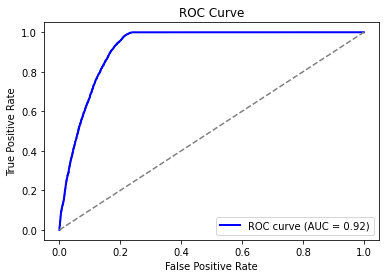

```python
plt.figure(figsize=(6,4))
plt.plot(fpr, tpr, color="blue", lw=2, label=f"ROC curve (AUC = {roc_auc:.2f})")
plt.plot([0, 1], [0, 1], color="gray", linestyle="--")
plt.xlabel("False Positive Rate")
plt.ylabel("True Positive Rate")
plt.title("ROC Curve")
plt.legend()
plt.show()
```

- The **ROC Curve** is a plot that shows the trade-off between the **True Positive Rate (TPR)** and the **False Positive Rate (FPR)** at various threshold settings.
- It helps in understanding how well the model can distinguish between two classes (in this case, readmitted vs. not readmitted).
- The **AUC (Area Under the Curve)** is computed, which quantifies the overall ability of the model to distinguish between classes.
- The **blue line** represents my model's performance.
- The **gray diagonal line** represents a random classifier (AUC = 0.5).
- A **higher AUC value** means better discrimination between classes.
- **Here, AUC = 0.92**, indicating that the model is highly effective at distinguishing between patients who will be readmitted and those who will not.

### Random Forest

To ensure we select the best model for **predicting patient readmission**, we will test an additional **Random Forest model** alongside Logistic Regression.

### **Why Random Forest?**

- Unlike Logistic Regression, which assumes a linear relationship, **Random Forest** can **capture non-linear patterns**.
- It is robust to **imbalanced datasets** and handles **missing values well**.
- Works well for structured healthcare data where feature interactions may impact predictions.

### **Evaluation Metrics:**

To compare **Logistic Regression vs. Random Forest**, we will assess:

- **Accuracy** → Measures overall correctness.
- **Precision & Recall** → Important for handling class imbalance.
- **F1 Score** → Balances precision and recall.
- **AUC-ROC** → Measures how well the model distinguishes between readmitted and non-readmitted patients.

```python
from sklearn.ensemble import RandomForestClassifier
from sklearn.metrics import accuracy_score, precision_score, recall_score, f1_score, roc_auc_score

rf = RandomForestClassifier(n_estimators=100, random_state=300)

rf.fit(X_train, y_train)

y_pred_rf = rf.predict(X_test)

accuracy_rf = accuracy_score(y_test, y_pred_rf)
precision_rf = precision_score(y_test, y_pred_rf)
recall_rf = recall_score(y_test, y_pred_rf)
f1_rf = f1_score(y_test, y_pred_rf)
auc_rf = roc_auc_score(y_test, rf.predict_proba(X_test)[:, 1])

print("Random Forest Model Performance:")
print(f"Accuracy: {accuracy_rf:.4f}")
print(f"Precision: {precision_rf:.4f}")
print(f"Recall: {recall_rf:.4f}")
print(f"F1 Score: {f1_rf:.4f}")
print(f"AUC-ROC: {auc_rf:.4f}")
```

```
Random Forest Model Performance:
Accuracy: 0.8927
Precision: 0.8397
Recall: 0.9894
F1 Score: 0.9084
AUC-ROC: 0.9262
```

## **Feature Importance Analysis Using SHAP**

To better understand **why the model predicts patient readmission**, I will use **SHAP (SHapley Additive Explanations)**. This method provides **interpretability** by explaining how each feature contributes to a prediction.

- This helps **identify the most influential features** in readmission prediction.
- Improves **trust in the model**, which is crucial for healthcare applications.
- Supports **feature selection**, leading to a more optimized model.

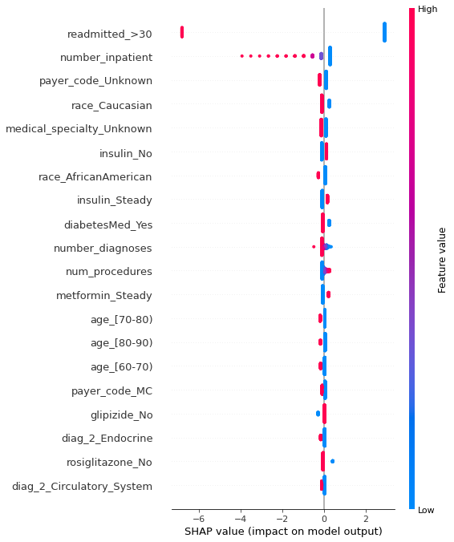

```python
import shap

small_X_test = X_test.sample(500, random_state=300)
explainer = shap.Explainer(logreg, small_X_test)
shap_values = explainer(small_X_test)

shap.summary_plot(shap_values, small_X_test)
```

### **SHAP Summary Plot Interpretation**

The SHAP (SHapley Additive exPlanations) summary plot shows the **importance of each feature** in predicting patient readmission.

```python
from sklearn.model_selection import RandomizedSearchCV
from sklearn.ensemble import RandomForestClassifier

param_grid = {
    'n_estimators': [50, 100],
    'max_depth': [10, 20, None],
    'min_samples_split': [2, 5],
    'min_samples_leaf': [1, 2]
}

random_search = RandomizedSearchCV(
    estimator=RandomForestClassifier(random_state=300),
    param_distributions=param_grid,
    n_iter=10,
    cv=3,
    scoring='accuracy',
    n_jobs=-1,
    verbose=2
)

random_search.fit(X_train, y_train)

best_rf = random_search.best_estimator_
y_pred_best_rf = best_rf.predict(X_test)
accuracy_best_rf = accuracy_score(y_test, y_pred_best_rf)

print("Best Hyperparameters:", random_search.best_params_)
print(f"Optimized Random Forest Accuracy: {accuracy_best_rf:.4f}")
```

```
Fitting 3 folds for each of 10 candidates, totalling 30 fits
Best Hyperparameters: {'n_estimators': 100, 'min_samples_split': 2, 'min_samples_leaf': 1, 'max_depth': 20}
Optimized Random Forest Accuracy: 0.8927
```

### Model Comparison

- Now I'll compare the **Optimized Random Forest model** with Logistic Regression and Base Random Forest (before tuning)

**Accuracy** → Overall correctness of the model.  
**Precision** → How many predicted positives were actually positive.  
**Recall** → How well the model captures actual positives.  
**F1-Score** → Balance between precision and recall.  
**AUC-ROC** → Measures the model’s ability to distinguish between classes.

```python
y_pred_logreg = logreg.predict(X_test)
y_pred_prob_logreg = logreg.predict_proba(X_test)[:, 1]
y_pred_prob_rf = rf.predict_proba(X_test)[:, 1]
y_pred_best_rf_prob = best_rf.predict_proba(X_test)[:, 1]

def evaluate_model(name, y_test, y_pred, y_pred_prob=None):
    print(f"Model Performance:")
    print(f"Accuracy: {accuracy_score(y_test, y_pred):.4f}")
    print(f"Precision: {precision_score(y_test, y_pred):.4f}")
    print(f"Recall: {recall_score(y_test, y_pred):.4f}")
    print(f"F1 Score: {f1_score(y_test, y_pred):.4f}")

    if y_pred_prob is not None:
        print(f"AUC-ROC: {roc_auc_score(y_test, y_pred_prob):.4f}")

evaluate_model("Logistic Regression", y_test, y_pred_logreg, y_pred_prob_logreg)

evaluate_model("Base Random Forest", y_test, y_pred_rf, y_pred_prob_rf)

evaluate_model("Optimized Random Forest", y_test, y_pred_best_rf, y_pred_best_rf_prob)
```

```
Model Performance:
Accuracy: 0.8915
Precision: 0.8391
Recall: 0.9876
F1 Score: 0.9073
AUC-ROC: 0.9240
Model Performance:
Accuracy: 0.8927
Precision: 0.8397
Recall: 0.9894
F1 Score: 0.9084
AUC-ROC: 0.9262
Model Performance:
Accuracy: 0.8927
Precision: 0.8371
Recall: 0.9938
F1 Score: 0.9087
AUC-ROC: 0.9293
```

### **Model Performance Comparison**

I compared three models:

- **Logistic Regression**
- **Base Random Forest (before hyperparameter tuning)**
- **Optimized Random Forest (after hyperparameter tuning)**
- Below are the results for **Accuracy, Precision, Recall, F1-Score, and AUC-ROC** for each model:

[output not shown]

### **Saving the Trained Model**

- I will save the **Optimized Random Forest model** using joblib.dump().

```python
!pip install joblib
```

```python
import joblib

joblib.dump(best_rf, "optimized_readmission_model.pkl")

print("Model saved successfully!")
```

```
Model saved successfully!
```

```python
from sklearn.preprocessing import StandardScaler, OneHotEncoder
from sklearn.compose import ColumnTransformer
from sklearn.pipeline import Pipeline

categorical_features = ['race', 'gender', 'payer_code', 'medical_specialty', 'diag_1', 'diag_2', 'diag_3',
                        'max_glu_serum', 'A1Cresult', 'metformin', 'repaglinide', 'nateglinide', 'chlorpropamide',
                        'glimepiride', 'acetohexamide', 'glipizide', 'glyburide', 'tolbutamide', 'pioglitazone',
                        'rosiglitazone', 'acarbose', 'miglitol', 'troglitazone', 'tolazamide', 'examide',
                        'citoglipton', 'insulin', 'glyburide-metformin', 'glipizide-metformin',
                        'metformin-rosiglitazone', 'metformin-pioglitazone', 'change', 'diabetesMed']

numerical_features = ['time_in_hospital', 'num_lab_procedures', 'num_procedures', 'num_medications',
                      'number_outpatient', 'number_emergency', 'number_inpatient', 'number_diagnoses']

df_train = pd.read_csv(r"C:\Users\user\Desktop\pr project\diabetic_data.csv")

age_mapping = {
    '0-10': 5, '10-20': 15, '20-30': 25, '30-40': 35, '40-50': 45,
    '50-60': 55, '60-70': 65, '70-80': 75, '80-90': 85, '90-100': 95
}

if 'age' in df_train.columns:
    df_train['age'] = df_train['age'].map(age_mapping)

important_features = [
    "num_lab_procedures",
    "num_procedures",
    "number_outpatient",
    "number_emergency",
    "number_inpatient",
    "number_diagnoses",
    "time_in_hospital",
    "num_medications"
]

preprocessor = ColumnTransformer([
    ("scaler", StandardScaler(), important_features)
])


preprocessor.fit(df_train)

print("Preprocessor created successfully!")

import joblib
joblib.dump(preprocessor, "preprocessor.pkl")
```

```
Preprocessor created successfully!
```

```
['preprocessor.pkl']
```

## Feature Importance: Random Forest

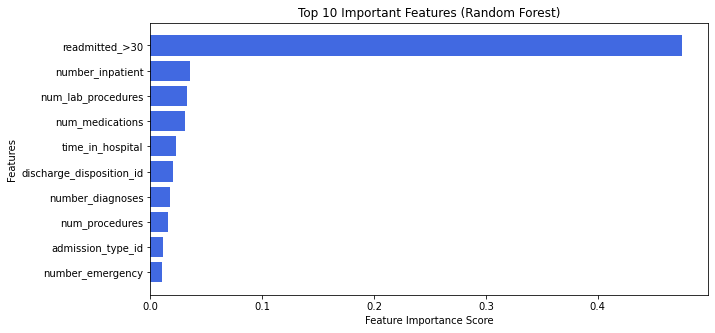

```python
rf_importances = rf.feature_importances_
feature_names = X_train.columns

# Sorting features by importance
rf_sorted_idx = np.argsort(rf_importances)[::-1]

# Plotting top 10 important features
plt.figure(figsize=(10, 5))
plt.barh(np.array(feature_names)[rf_sorted_idx][:10], rf_importances[rf_sorted_idx][:10], color='royalblue')
plt.xlabel('Feature Importance Score')
plt.ylabel('Features')
plt.title('Top 10 Important Features (Random Forest)')
plt.gca().invert_yaxis()
plt.show()
```

## Feature Importance: Logistic Regression

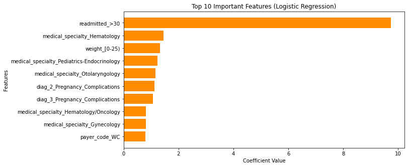

```python
# Extract coefficients from trained Logistic Regression model
lr_coefficients = np.abs(logreg.coef_).flatten()
lr_sorted_idx = np.argsort(lr_coefficients)[::-1]

# Plotting top 10 important features for Logistic Regression
plt.figure(figsize=(10, 5))
plt.barh(np.array(feature_names)[lr_sorted_idx][:10], lr_coefficients[lr_sorted_idx][:10], color='darkorange')
plt.xlabel('Coefficient Value')
plt.ylabel('Features')
plt.title('Top 10 Important Features (Logistic Regression)')
plt.gca().invert_yaxis()
plt.show()
```

## Feature Importance: Optimized Random Forest

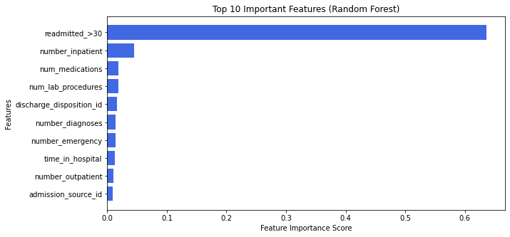

```python
rf_importances = best_rf.feature_importances_

feature_names = X_train.columns

sorted_idx = np.argsort(rf_importances)[::-1]

# Select top 10 features
top_n = 10
top_features = [feature_names[i] for i in sorted_idx[:top_n]]
top_importances = rf_importances[sorted_idx[:top_n]]

# Plot feature importance
plt.figure(figsize=(10, 5))
plt.barh(top_features[::-1], top_importances[::-1], color='royalblue')
plt.xlabel("Feature Importance Score")
plt.ylabel("Features")
plt.title("Top 10 Important Features (Random Forest)")
plt.show()
```

## Readmission Status Count - Bar Char

[figure not shown]

```python
plt.figure(figsize=(6, 4))
sns.countplot(x=df["readmitted_>30"])
plt.xlabel("Readmission Status")
plt.ylabel("Count")
plt.title("Readmission Status Count")
plt.xticks([0, 1], ["Not Readmitted", "Readmitted"])
plt.show()
```

## Readmission Rate vs. Hospital Stay Duration

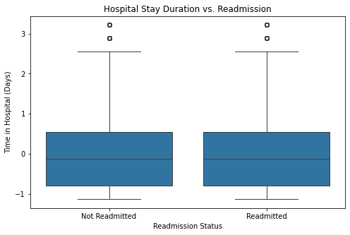

```python
plt.figure(figsize=(8, 5))
sns.boxplot(x=df["readmitted_>30"], y=df["time_in_hospital"])
plt.xlabel("Readmission Status")
plt.ylabel("Time in Hospital (Days)")
plt.title("Hospital Stay Duration vs. Readmission")
plt.xticks([0, 1], ["Not Readmitted", "Readmitted"])
plt.show()
```

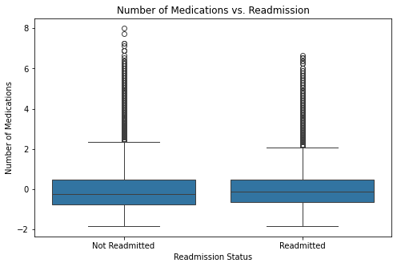

```python
plt.figure(figsize=(8, 5))
sns.boxplot(x=df["readmitted_>30"], y=df["num_medications"])
plt.xlabel("Readmission Status")
plt.ylabel("Number of Medications")
plt.title("Number of Medications vs. Readmission")
plt.xticks([0, 1], ["Not Readmitted", "Readmitted"])
plt.show()
```

## Conclusion

This project provides a **data-driven solution** for hospitals to proactively **identify high-risk diabetic patients**, improve post-discharge care, and reduce unnecessary readmissions, ultimately **enhancing patient outcomes and optimizing hospital resources**.